# Analysis of Rat Sightings in New York City

# Appendix: Secondary Model

We have a secondary model for K-Means Clustering. This requires some preprocessing: converting all features to a numerical representation and selecting an accurate classification model, from which we can find the most important features. Then we find the optimal k by calculating the distortions and applying the elbow method, as well as deriving the silhouette score for multiple values of k. Then, we extract the 4 most important features and perform PCA dimensionality reduction. The K-Means Clustering model can then be trained with the PCA labels and visualized.

First, transform our data to be numerical using one-hot encoding, and normalize all numerical features.

```python
import numpy as np
import pandas as pd
from sklearn.model_selection import train_test_split, cross_val_score, StratifiedKFold
from sklearn.preprocessing import StandardScaler
from sklearn.metrics import accuracy_score, classification_report, silhouette_score

import matplotlib.pyplot as plt
import matplotlib
from sklearn.cluster import KMeans, DBSCAN
from sklearn.decomposition import PCA
from matplotlib.colors import Normalize
from matplotlib.lines import Line2D

import ast
pd.set_option('display.max_columns', None)
from scipy.spatial.distance import cdist

import matplotlib.pyplot as plt
import seaborn as sns
import warnings

warnings.filterwarnings("ignore", category=FutureWarning, module="seaborn")

from sklearn.tree import DecisionTreeClassifier
from sklearn.neighbors import KNeighborsClassifier
from sklearn.linear_model import LogisticRegression
from sklearn.ensemble import RandomForestClassifier

# Convert categorical location types with one-hot encoding
def encode_location_type(value, residential_location, nonresidential_location, other_location):
    residential_location.append(0)
    nonresidential_location.append(0)
    other_location.append(0)
    if value in residential_mapping.values():
      residential_location[-1] = 1
    elif value in ['Other', 'Other (Explain Below)']:
      other_location[-1] = 1
    else:
      nonresidential_location[-1] = 1

# Convert boroughs with one-hot encoding
def encode_borough(value, manhattan, brooklyn, queens, staten_island, bronx):
    manhattan.append(0)
    brooklyn.append(0)
    queens.append(0)
    staten_island.append(0)
    bronx.append(0)
    if value.lower() == 'manhattan':
      manhattan[-1] = 1
    elif value.lower() == 'brooklyn':
      brooklyn[-1] = 1
    elif value.lower() == 'queens':
      queens[-1] = 1
    elif value.lower() == 'staten island':
      staten_island[-1] = 1
    elif value.lower() == 'bronx':
      bronx[-1] = 1

# Make df entirely numerical data
# Use one-hot encoding on categorical data
# Consider zip code numerical data because the numbers are generally grouped/ordered by physical location
noncategorical_df = income_rat_df.copy()
residential_location = []
nonresidential_location = []
other_location = []
for val in noncategorical_df['Location Type']:
    encode_location_type(val, residential_location, nonresidential_location, other_location)

manhattan = []
brooklyn = []
queens = []
staten_island = []
bronx = []
for val in noncategorical_df['Borough']:
    encode_borough(val, manhattan, brooklyn, queens, staten_island, bronx)

# Add binary features from encoding
noncategorical_df['Residential Location'] = residential_location
noncategorical_df['Nonresidential Location'] = nonresidential_location
noncategorical_df['Other Location'] = other_location
noncategorical_df['Manhattan'] = manhattan
noncategorical_df['Brooklyn'] = brooklyn
noncategorical_df['Queens'] = queens
noncategorical_df['Staten Island'] = staten_island
noncategorical_df['Bronx'] = bronx

# Drop all categorical features (except Rat Concentration, the output column) and Month
noncategorical_df = noncategorical_df.drop(columns=['Created Date', 'Community Board', 'Location Type', 'Borough', 'Year-Month', 'Month'])

noncategorical_df
```

|  | ZIP | Households | Year | Latitude | Longitude | Average Income (Dollars) | Rat Concentration | Is_Summer | Residential Location | Nonresidential Location | Other Location | Manhattan | Brooklyn | Queens | Staten Island | Bronx |
| --- | --- | --- | --- | --- | --- | --- | --- | --- | --- | --- | --- | --- | --- | --- | --- | --- |
| 0 | 10002 | 34737 | 2021 | 40.712790 | -73.994416 | 40021.50 | Low | 0 | 1 | 0 | 0 | 1 | 0 | 0 | 0 | 0 |
| 1 | 10002 | 34737 | 2021 | 40.720000 | -73.989949 | 40021.50 | Low | 0 | 1 | 0 | 0 | 1 | 0 | 0 | 0 | 0 |
| 2 | 10002 | 34737 | 2021 | 40.721333 | -73.983336 | 40021.50 | Low | 0 | 1 | 0 | 0 | 1 | 0 | 0 | 0 | 0 |
| 3 | 10002 | 34737 | 2021 | 40.715378 | -73.992324 | 40021.50 | Low | 0 | 0 | 0 | 1 | 1 | 0 | 0 | 0 | 0 |
| 4 | 10002 | 34737 | 2021 | 40.715874 | -73.990852 | 40021.50 | Low | 0 | 1 | 0 | 0 | 1 | 0 | 0 | 0 | 0 |
| ... | ... | ... | ... | ... | ... | ... | ... | ... | ... | ... | ... | ... | ... | ... | ... | ... |
| 64540 | 11435 | 17950 | 2011 | 40.687739 | -73.802493 | 54596.25 | Low | 0 | 1 | 0 | 0 | 0 | 0 | 1 | 0 | 0 |
| 64541 | 11435 | 17950 | 2011 | 40.706788 | -73.808957 | 54596.25 | Low | 0 | 1 | 0 | 0 | 0 | 0 | 1 | 0 | 0 |
| 64542 | 11435 | 17950 | 2011 | 40.691843 | -73.807817 | 54596.25 | Low | 0 | 1 | 0 | 0 | 0 | 0 | 1 | 0 | 0 |
| 64543 | 11435 | 17950 | 2011 | 40.696941 | -73.806587 | 54596.25 | Low | 0 | 0 | 1 | 0 | 0 | 0 | 1 | 0 | 0 |
| 64544 | 11435 | 17950 | 2011 | 40.715034 | -73.823190 | 54596.25 | Low | 0 | 1 | 0 | 0 | 0 | 0 | 1 | 0 | 0 |

64545 rows × 16 columns

Next, find the most accurate classifier. We'll use it to find the 4 most important features to consider in our K-Means Clustering.

```python
from sklearn.tree import DecisionTreeClassifier
from sklearn.neighbors import KNeighborsClassifier
from sklearn.linear_model import LogisticRegression
from sklearn.ensemble import RandomForestClassifier

# Initialize X and y
X = noncategorical_df.drop(columns=['Rat Concentration'])
y = noncategorical_df['Rat Concentration']

seed = 42
test_size=0.2

# Split training/testing datasets
X_train, X_test, y_train, y_test = train_test_split(X, y, test_size=test_size, random_state=seed)

# Normalize training and test datasets
scaler = StandardScaler()
scaler.fit(X_train)
X_train_scaled = scaler.transform(X_train)
scaler.fit(X_test)
X_test_scaled = scaler.transform(X_test)

# Initialize classification models
models = {
  "DecisionTreeClassifier": DecisionTreeClassifier(),
  "KNeighborsClassifier": KNeighborsClassifier(),
  "LogisticRegression": LogisticRegression(),
  "RandomForestClassifier": RandomForestClassifier()
}

# Perform k-fold validation (5 folds) to determine the accuracy of each model
k_folds = 5
skf = StratifiedKFold(n_splits=k_folds, shuffle=True, random_state=seed)
for model_name, model in models.items():
    np.random.seed(seed)
    scores = cross_val_score(model, X_train_scaled, y_train, cv=skf)
    print(model_name + ": mean, " + str(scores.mean()) + " std, " + str(scores.std()))
```

```
DecisionTreeClassifier: mean, 0.6520839182286857 std, 0.005376828086572364
KNeighborsClassifier: mean, 0.6463707673109461 std, 0.0008585036874630779
LogisticRegression: mean, 0.514466648195037 std, 0.0022800766605120355
RandomForestClassifier: mean, 0.6660858329226096 std, 0.005574133400029941
```

Observe that the most accurate model is the Random Forest Classifier with the highest mean.

```python
# Train RFC model using the training data
np.random.seed(seed)
models['RandomForestClassifier'].fit(X_train_scaled, y_train)

# Evaluate the performance via the classification report
y_pred = model.predict(X_test_scaled)
accuracy = accuracy_score(y_test, y_pred)
print(f"Accuracy of RandomForestClassifier: {accuracy:.2f}")
report = classification_report(y_test, y_pred)
print(report)
```

```
Accuracy of RandomForestClassifier: 0.66
              precision    recall  f1-score   support

        High       0.78      0.80      0.79      5924
         Low       0.51      0.48      0.49      2808
      Medium       0.57      0.58      0.57      4177

    accuracy                           0.66     12909
   macro avg       0.62      0.62      0.62     12909
weighted avg       0.66      0.66      0.66     12909
```

Now extract and display the feature importances from the most accurate model.

```python
importances = models['RandomForestClassifier'].feature_importances_

feature_importance_df = pd.DataFrame({
    'feature': X.columns.tolist(),
    'importance': importances
})

ranked_importances = feature_importance_df.sort_values(by='importance', ascending=False)
print(ranked_importances.head(15))
```

```
                     feature  importance
4                  Longitude    0.274092
3                   Latitude    0.273710
2                       Year    0.170078
6                  Is_Summer    0.139634
1                 Households    0.050098
5   Average Income (Dollars)    0.049840
0                        ZIP    0.021284
7       Residential Location    0.006270
8    Nonresidential Location    0.005577
9             Other Location    0.005267
11                  Brooklyn    0.001267
14                     Bronx    0.000890
12                    Queens    0.000862
10                 Manhattan    0.000618
13             Staten Island    0.000513
```

Next, calculate and graph distortions to determine the optimal number of clusters for K-Means.

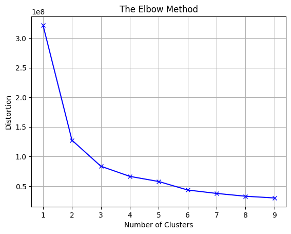

```python
## Find ideal number of clusters
distortions = []
inertias = []
mapping1 = {}
mapping2 = {}
K = range(1, 10)

for k in K:
    # Building and fitting the model
    kmeansModel = KMeans(n_clusters=k, random_state=seed).fit(X)

    # Append your distortion value
    distortions.append(sum(np.min(cdist(X, kmeansModel.cluster_centers_, 'euclidean'), axis=1)**2) / X.shape[0])
    inertias.append(kmeansModel.inertia_)

    # Save it to mapping1 and mapping2
    mapping1[k] = distortions[-1]
    mapping2[k] = inertias[-1]

# Plot
plt.plot(K, distortions, 'bx-')
plt.xlabel('Number of Clusters')
plt.ylabel('Distortion')
plt.title('The Elbow Method')
plt.grid()
plt.show()
```

Let the optimal k = 3.

```python
num_clusters = 3
```

Use the KElbowVisualizer library to verify the result and calculate the silhouette score.

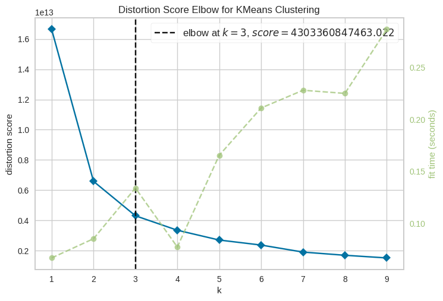

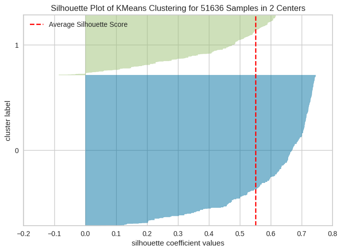

```
0.551907183857268
```

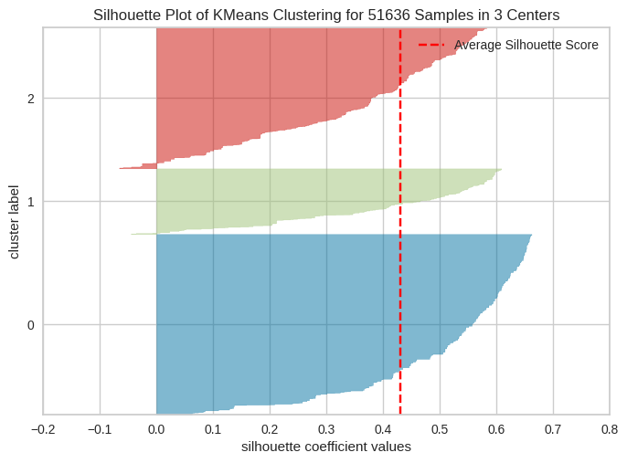

```
0.43120101806879874
```

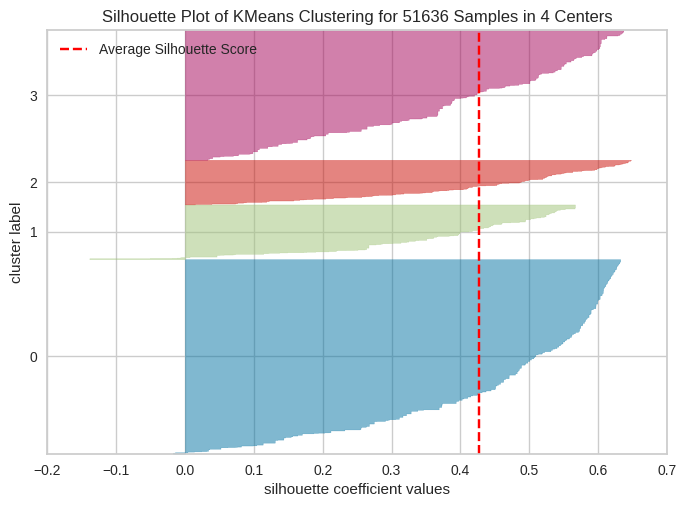

```
0.42685805387044257
```

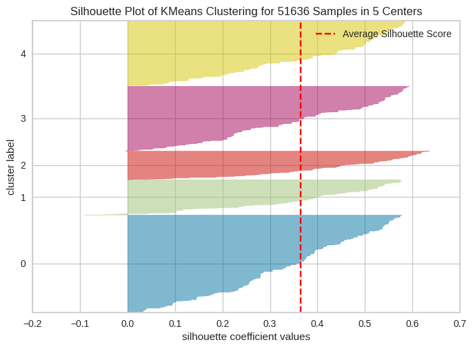

```
0.3639684279497593
```

```python
from sklearn import datasets
from sklearn.cluster import KMeans
import matplotlib.pyplot as plt
from yellowbrick.cluster import SilhouetteVisualizer
from yellowbrick.cluster import KElbowVisualizer

# Instantiate the K-Means Clustering model and visualizer
model = KMeans(random_state=seed)
model.fit(X_train)

# Display the KElbowVisualizer plot
visualizer = KElbowVisualizer(model, k=(1, 10))
visualizer.fit(X_train)
visualizer.show()

# Display the SilhouetteVisualizer plot for num_clusters=2 to 5
for i in range(2,6):
    model2 = KMeans(i, random_state=seed)

    # Display SilhouetteVisualizer plot
    visualizer2 = SilhouetteVisualizer(model2, colors='yellowbrick')
    visualizer2.fit(X_train)
    visualizer2.show()

    # Get the silhouette score from the plot
    score = visualizer2.silhouette_score_
    print(score)
```

Now, we can perform K-Means Clustering with k=3 using the most important features, as determined by the Random Forest Classifier.

```python
features = ['Latitude', 'Longitude', 'Year', 'Is_Summer']
X = noncategorical_df[features]
print(X)

# Normalize
scaler = StandardScaler()
X_scaled = scaler.fit_transform(X)
```

```
        Latitude  Longitude  Year  Is_Summer
0      40.712790 -73.994416  2021          0
1      40.720000 -73.989949  2021          0
2      40.721333 -73.983336  2021          0
3      40.715378 -73.992324  2021          0
4      40.715874 -73.990852  2021          0
...          ...        ...   ...        ...
64540  40.687739 -73.802493  2011          0
64541  40.706788 -73.808957  2011          0
64542  40.691843 -73.807817  2011          0
64543  40.696941 -73.806587  2011          0
64544  40.715034 -73.823190  2011          0

[64545 rows x 4 columns]
```

Perform PCA (t-SNE takes too long on 65k data points).

```python
def apply_pca(X_scaled, n_components=2):
    pca = PCA(n_components=n_components)
    X_pca = pca.fit_transform(X_scaled)
    return pca, X_pca

pca, X_pca = apply_pca(X_scaled)
```

Perform K-Means Clustering.

```python
def apply_kmeans(X, n_clusters, random_state=seed):
    kmeans = KMeans(n_clusters=n_clusters, random_state=random_state)
    labels = kmeans.fit_predict(X)
    return labels

# Apply K-means to PCA results
pca_labels = apply_kmeans(X_pca, n_clusters = num_clusters)
```

Visualize clustering with the PCA results.

```
[[-0.41995272  1.83551377]
 [-0.32779757  1.82888147]
 [-0.26094571  1.82183756]
 ...
 [ 0.9447629  -1.26053253]
 [ 0.99332263 -1.26328347]
 [ 0.98518819 -1.25196853]]
(64545, 2)
(64545,)
```

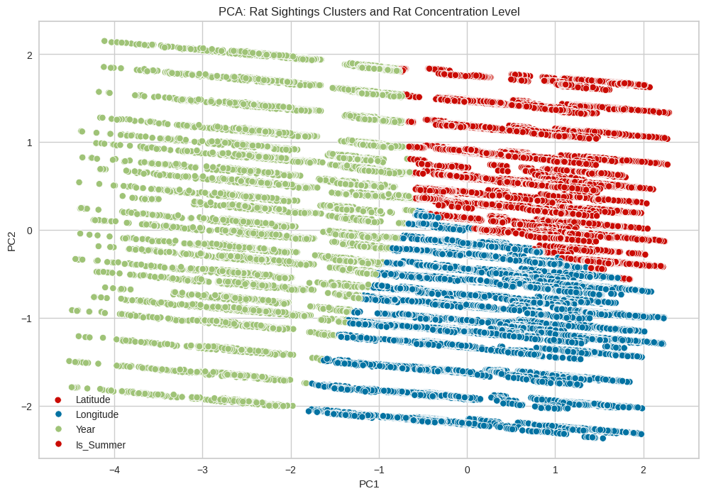

```python
def plot_clusters(X, labels, rating, title, xlabel, ylabel):
    fig, ax = plt.subplots(figsize=(12, 8))
    kmeans = KMeans(n_clusters=3, random_state=seed).fit(X)

    noncategorical_df['Cluster'] = pd.Categorical(kmeans.labels_)
    sns.scatterplot(x=X[:, 0],y=X[:, 1], hue="Cluster", data=noncategorical_df,s=45,legend="full")
    plt.legend(labels=[features[0], features[1], features[2], features[3]])

    plt.title(title)
    plt.xlabel(xlabel)
    plt.ylabel(ylabel)
    plt.show()

print(X_pca)
print(X_pca.shape)
print(noncategorical_df['Rat Concentration'].shape)

# Visualize PCA results
plot_clusters(X_pca, pca_labels, noncategorical_df['Rat Concentration'],
              'PCA: Rat Sightings Clusters and Rat Concentration Level', 'PC1', 'PC2')
```